# Getting Gene Groupings from DAVID Functional Classification Tool

`EMVS()` function requires `grouping` as a parameter. For a given set of genes, we can come up with a functional classification (or a “grouping”) of the genes. One tool we suggest is the [DAVID Functional Classification tool](https://david.ncifcrf.gov/gene2gene.jsp). Here, we provide a brief tutorial on how to obtain gene grouping using this tool.

## Step 1. Enter Gene List

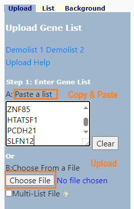

## Step 2. Choose Gene ID Type

Next, we need to specify the ID Type of the genes entered. Our example uses the OFFICIAL GENE SYMBOL. If you know the species of the genes, you can specify in Step 2a. Our genes are Homo Sapiens.

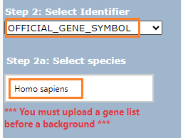

## Step 3. Submit and Download

Then we specify the List Type and submit. The Tool will return the classification result. You many download it as a txt file. (Click DownLoad File -> Right click on browser -> Save as…)

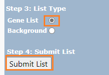

[figure not shown]

## Step 4. Get Grouping

```r
fp <- system.file("eg_fx_classification.txt", package="BayesMultiomics")
gene_grouping <- DAVIDGeneGrouping(eg_gene_symbols, fp)
gene_grouping
```

[output not shown]